# Using Zooglider Zonar data in R

# Introduction

## Zooglider

*Zooglider* a new generation of gliders able to characterise the structure of zooplankton communities through high resolution optical recordings, quantify biological or physical boundaries zones and relative biological abundances through multi-frequency acoustic recordings with concurrent physical recordings of ambient fluorescence, temperature and salinity. For a full description of *Zooglider* please refer to[@ohman_zooglider_2019].

## Acoustics background - How to get from raw acoustic data to Sv data

**Note:** *Here we follow the nomenclature defined in MacLennan et al [-@maclennan_consistent_2002] or where updated Demer et al [-@demer_calibration_2015]. For people not used to fisheries acoustic nomencalture, it is handy to remember that lower case variable names refer to coefficients (linear units) while uppercase variable names refer to strengths (log units, generally dB). Subscripts should have logical namings, one exception might be subscript a - refering to metric references and subscript A - refering to nautical miles.*

Acoustic recordings deliver high resolution information allowing for a quantification of the biological productivity through analysis of the net acoustic backscatter, segregated into functional groups based on multifrequency backscattering characteristics of marine organisms [@koslow_role_2009,@powell_changes_2015 @simmonds_fisheries_2008, @stanton_acoustic_1996].  
Zooglider is equipped with the Zonar system. The Zonar system consists of two single beam echosounders, operated at 200 and 1000 kHz. In normal operation Zonar will emit one burst of 4 pings at each of the two frequencies. A summary of the current Zonar settings can be found in the calibration table below.

Typical acoustic echogram visualizations, generally involve a time component on the x-axis and a depth or range component on the y-axis. The fill values are often expressed as Scattering volume (*Sv*) or Target Strength (*TS*), which are metrics that can be derived from the raw Zonar count data.

First the data point depth is computed:
We can calculated the distance from the transducer of the first sampling point ($z_0$)as:
$$z_0=(t_b + \frac{\tau}{2}) \frac{c}{2 * 1000}$$
where $t_b$ is the blanking time (typically 1) in ms, $\tau$ is the pulse duration in ms and $c$ is the sound speed in $ms^{-1}$. Now we can compute the distance from the transducer face of each sampling point ($d_z$) with $d_t$ the sampling interval in ms as:
$$d_z = n_{scan}*\frac{c}{2 * 1000}*d_t * 0.001 + z_0$$
to get the true depth of each sampling point, we have to add the depth of the glider at the time of the ping emission ($z_{glider}$) and multiply the euclidean distance of the sampling point from the transducer face by the cosinus of the glider pitch ($p_{glider}$):
$$z= z_{glider} + d_z * cos(p_{glider})$$

Sv in dB re 1m^2m{-3} can be computed as:
$$Sv = E(R) - SL - 10 log_{10}(\frac{c*\tau}{2}) - \Psi + 20log_{10}(d_z) + 2\alpha d_z + G = 10 * log_{10}(\sum\frac{\sigma_{bs}}{V})$$
with $E(R)$ the acoustic signal express in dB re 1V, $SL$ the source level in dB, $c$ the sound speed in the ambient fluid medium in $ms^{-1}$, $\tau$ the pulse duration in $s$, $\Psi$ the equivalent two-way beam angle (solid angle subtended by an ideal conical beam that would produce the same volume integral as the square of the normalizedtransducer directivity) in steradians or dB re 1 sr, $dz$ the range to the target (The direct-path distance between objects, e.g. the transducer face and the target) in m, $\alpha$ the absorption coefficient, a metric of absorption loss in dB $m^{-1}$ and $G$ the on-axis calibration gain in dB re 1. $\sigma_{bs}$ is the backscattering cross-section [$m^2$].

Analoguously to Sv, TS can be computed as:
$$TS = E(R) - SL -40log10(d_z) + 2(\alpha d_z) + G = 10*log_{10}(\sigma_{bs})$$

The acoustic raw data read from Zonar is raw count data $ac_{raw}$, where a given count ($gn$ generally 40) can be used to translate the count data into *dB re 1V* ($E(R)_{raw}$):
$$E(R)_{dB} = \frac{ac_{raw}}{gn}$$
or expressed in it’s linear form:
$$E(R)_{lin} = 10^{\frac{E(R)_{dB}}{10}}$$

SL is generally measured directly in the instrument. None such sensitivity measurements are available. Therefore SL is approximated, using the calibration data. During the calibration process measurements without any target in the pool are taken. These are labelled calibration noise measurements ($NL$). Asuming the background noise to be approximating zero, these measurements can be taken as an approximation of SL. SL now becomes:
$$SL=\frac{NL}{gn} + G_0+40log_{10}(d_c+2\alpha_c d_c)$$
with $d_c$ the measurement range and $\alpha_c$ the absorption coefficient given ambient calibration conditions and $G0$ the system gain.

## Calibration

Calibration is executed, largely following calibration procedures described by Demer et al [-@demer_calibration_2015], using a 10 mm tungsten carbide sphere. Calibration is completed on a regular basis in a purpose build pool. For the purpose of the calibration, the transducers are dismounted from the glider and mounted on a plate. The transducer is driven by a connected laptop. The position of the transducer can be adjusted vertically and it can be rotated. A 10 mm sphere with expected $TS_0$ in calibration conditions of -53.47 dB at 200 kHz and -50.92 at 1000 kHz is suspended at a distance of 5 m from the transducer face. Through systematic vertical movement and rotation, beam mapping can be achieved. On-axis calibraiton is then executed at the vertical position and the rotation, where the maximum backscatter was recorded.
$TS_0$ expressed in in raw acoustic dB values ($TS_c$) becomes:
$$TS_c = TS_0 + SL - 40log_{10}(d_c) - 2\alpha_c$$
The on-axis calibration gain can be approximated as:
$$G_{cal}=TS_c - TS_m$$
with $TS_m$ the measured raw on-axis values with the sphere positioned in the center of the beam expressed in dB re V.
$\Psi$ the equivalent beam angle si calculated as:
$$\Psi = 10log_{10}(\frac{5.78}{(ka)^2})$$
The wave length $\lambda$ can be computed as: $lambda = \frac{c}{f}$. The wave number $k$ is defined as $k=2\frac{\pi}{\lambda}$.
The active radius ($a$) is
$$a=\frac{1.6}{k *sin(\frac{\theta_{3dB}}{2})}$$
with $\theta_{3dB}$ the angle from the transducer beam axis to the point of half-power.

# Getting started with ZooDVM

## Installing packages

For this tutorial we need the *ZooDVM* and *ZooScatR* package, both are available from Github, from the UCSD zgdata shared drive.  
#### devtools to install packages from GitHub within R

Installing packages from GitHub requires the *devtools* pakcage to be installed. We can use the below code to check if devtools is installed and install it if it isn’t:

```r
if('devtools' %in% installed.packages()){
  message(Sys.time(), ': devtools is already available, no further action required. The install version is ',packageVersion('devtools'))
}else{
  install.packages('devtools',dependencies = TRUE, INSTALL_opts = '--no-lock')
}
library(devtools)
```

#### Check for other required packages

Let’s check if all packages needed are available. For this pupose we can create a little helper function:

```r
check.packages <- function(pkg){
  new.pkg <- pkg[!(pkg %in% installed.packages()[, "Package"])]
  if (length(new.pkg))
    install.packages(new.pkg, dependencies = TRUE, INSTALL_opts = '--no-lock')
  sapply(pkg, require, character.only = TRUE)
}
```

Now we can simply check the availability of any package, see below as an example:

```r
check.packages(c('ggplot2','dplyr','suncalc','ncdf4','pracma', 'tidyr', 'marmap','knitr','interp','mgcViz','mgcv'))
```

```
## ggplot2   dplyr suncalc   ncdf4  pracma   tidyr  marmap   knitr  interp  mgcViz
##    TRUE    TRUE    TRUE    TRUE    TRUE    TRUE    TRUE    TRUE    TRUE    TRUE
##    mgcv
##    TRUE
```

## Installing ZooDVM and ZooScatR

Now we can proceed with installing *ZooDVM* and *ZooScatR* if needed.

Checking if ZooScatr and ZooDVM are available and installing them if not (with the command below all depencies and vignettes will be installed with the packages):

```r
if(!('ZooDVM' %in% installed.packages())){
  devtools::install_github('SvenGastauer/ZooDVM', build_vignettes = TRUE, dependencies = TRUE)
}else{message(Sys.time(), ': ZooDVM is already installed')}

if(!('ZooScatR' %in% installed.packages())){
  devtools::install_github('AustralianAntarcticDivision/ZooScatR', build_vignettes = TRUE, dependencies = TRUE)
}else{message(Sys.time(), ': ZooScatR is already installed')}

library(ZooDVM)
library(ZooScatR)
library(ggplot2) #for other plotting needs
library(dplyr) # for fast and clean data manipulation
library(tidyr) # for clean data manipulation
```

### Troubleshoot installation errors

If you get errors concerning Rcpp or devtools or other packages tha tneed compilation, we will have to install the latest version of Rtools (windows users), devtools and Rcpp.  
Please note that the below packages are unrelated to ZooDVM and the author has noinfluence on the development of these packages.

If you get errors concerning [Devtools](https://cran.r-project.org/web/packages/devtools/index.html), try reinstalling devtools using:

```r
 install.packages('devtools',dependencies = TRUE, INSTALL_opts = '--no-lock')
```

If you get errors concerning [Rcpp](https://cran.r-project.org/web/packages/Rcpp/index.html) or other packages that need compiling, make sure to install it using *dependencies = TRUE, INSTALL_opts = ‘–no-lock’* options:

```r
 install.packages('Rcpp',dependencies = TRUE, INSTALL_opts = '--no-lock')
```

[Rtools](https://cran.r-project.org/bin/windows/Rtools/) - Windows - At the time of writing a new version of Rtools and the way it is used has been implemented, which might cause some trouble. If you get a message such as:  
`WARNING: Rtools is required to build R packages, but is not currently installed.`  
Install Rtools by downloading the required binary package from cran:  
* [Windows users](https://cran.r-project.org/bin/windows/Rtools/)

# Getting Sv data into R

First we will have to define the directory where we can find all the needed data and have a look at the available missions:

```r
path = 'C:\\Users\\sven\\Documents\\Zonar\\data\\csv_zonar\\'
mm = get_mission(path)
```

```
## 2020-07-27 16:35:38: a total of 16 missions were found.
```

The *ZooDVM* get_mission() function by default provides us with a list container containing 4 sets. One list containing the 200 kHz, one the 1000 kHz and one the Sv Delta filenames and paths. A fourth list contains just the mission names. CUrrently the following missions are avaialble:

| Index | Mission |
| --- | --- |
| 1 | 2017_03_ZG_Rendezvous |
| 2 | 2017_07_SD_Trough_1 |
| 3 | 2017_09_SD_Trough_2 |
| 4 | 2017_11_SD_Trough_3 |
| 5 | 2018_01_SD_Trough_4 |
| 6 | 2018_04_SD_Trough_5 |
| 7 | 2018_05_LJ_Canyon_SN068_trials |
| 8 | 2018_06_SD_Trough_6 |
| 9 | 2018_07_SD_Trough_7 |
| 10 | 2018_10_SD_Trough_8 |
| 11 | 2018_11_SD_Trough_9 |
| 12 | 2019_01_SD_Trough_10 |
| 13 | 2019_05_SD_Trough_11 |
| 14 | 2019_07_SD_Trough_12 |
| 15 | 2019_08__PtSur_filament |
| 16 | 2020_01_LJ_Canyon_1 |

.

## Reading Sv data for one mission

We can read the Sv data at 200 kHz, 1000 kHz and Sv delta with one function:

```r
sel=15
mission = mm$missions[sel]
Sv = get_sv(path,sel)
```

```
## 2020-07-27 16:35:38: a total of 16 missions were found.
```

```
## 2020-07-27 16:35:38: Selected mission - 2019_08__PtSur_filament
```

The data is now found in `Sv$data$'1000kHz'`, `Sv$data$'200kHz'`, `Sv$data$'Delta'` and the plots are in `Sv$plots` with the same endings, additionally it contains the gps infomation in `Sv$gps`.  
Let’s have a look at the basic plots:

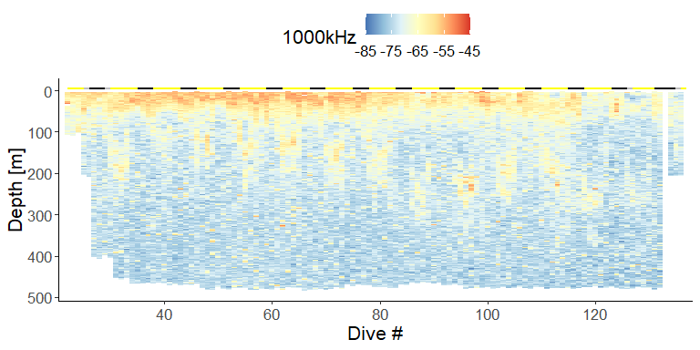

```r
Sv$plots$`1000kHz`
```

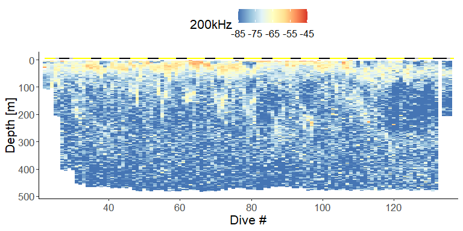

```r
Sv$plots$`200kHz`
```

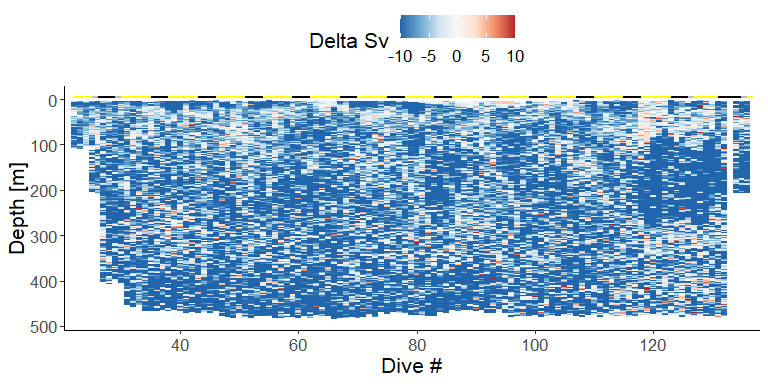

```r
Sv$plots$`Delta`
```

We can also use the obtained information to make some adjustments to the plot through the `plot_sv()` function, like choosing another color palette:

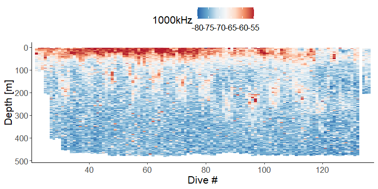

```r
plot_sv(Sv$data$`1000kHz`,cmaps="RdBu", svmax=-55, svmin=-80)
```

To add the day/night bar on top we can do:

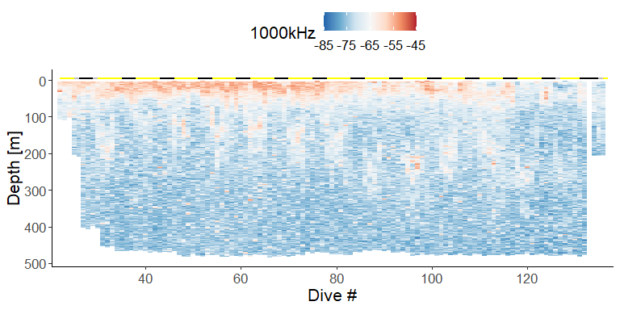

```r
plot_sv(Sv$data$`1000kHz`,gps=Sv$gps,cmaps="RdBu")
```

## Processing the acoustic Sv data

Currently there are a few possibilities in ZooDVM to manipulate the Sv data.  
- Running statistics (using a window size) `filter2d()` - Anomality calculations `anomaly()`  
are available.

### Running window filters

Let’s for example apply a median filter with a window size of 3x3 on the 1000 kHz Sv data. We can then use the `plot_sv()` function to create a typical echogram plot:

```r
med3x3 = filter2d(data=Sv$data$`1000kHz`,
                  x=3,y=3, #set the x and y window size
                  xval='Dive', #default is 'Dive' which is the name of the x axis variable
                  yval='Depth_r',#default is 'Depth_r' which is the name of the y axis variable
                  val='Sv', #default is 'Sv' which is the name of the fill variable
                  log=TRUE, #default is TRUE which means that the input variable is in log space
                  fun = 'median') #the function to be computed
```

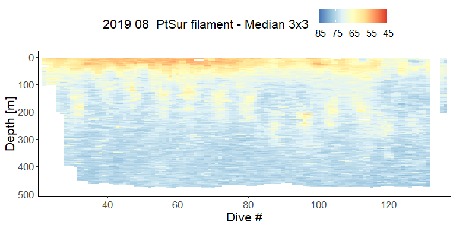

```r
plot_sv(med3x3, nam=paste(str_replace_all(mission,'_',' '), expression("- Median 3x3 ", Sv['1000kHz'])))
```

Similarly we could also create a mean 5x5 filter. Here we just adjust the fun - function variable, and the window size in x and y direction. All other values are left untouched as these are the standard function values. For demonstration purposes, we also add a day/night bar to the plot:

```r
mean5x5 = filter2d(data=Sv$data$`1000kHz`, x=5,y=5,fun = 'mean')
```

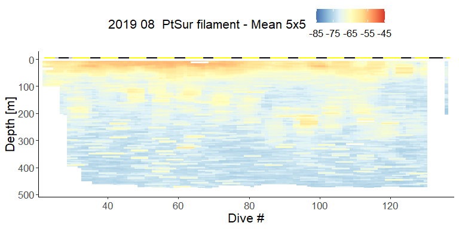

```r
plot_sv(mean5x5, Sv$gps, nam=paste(str_replace_all(mission,'_',' '), expression("- Mean 5x5 ", Sv['1000kHz'])))
```

`fun` could be repalced by an arbitrary function such as min, max, sd, var or similar.

### Anomaly filters

For the anomaly case, anomalies are simply defined as $x_i - 10*log_{10}f(10^{\frac{x}{10}})$ with $x_i$ a datapoint and $f(x)$ a function applied to all x. With an input of Sv data in dB / log space, results of this funciton will be in dB as well. As such, we could for example define the mean value for each depth bin as the background and substract if from all data to receive an anomaly map. Alternatively funcitons such as median or others could be used. The output of the `anomaly()` will create two new variables `SvAnomal`, which is the above described function and `scaledAnomaly` which is the same function, but scaled to [-1,1] using $2*\frac{y_i-min(y)}{max(y)-min(y)}-1$ with $y$ the computed anomaly value and $y_i$ the anomaly value at position $i$:

```r
ano1 = anomaly(Sv$data$`1000kHz`, fun='mean')
```

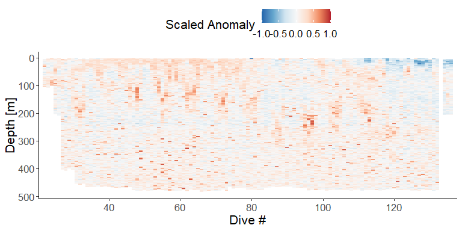

```r
#plotting the scaled anomaly
plot_sv(ano1)
```

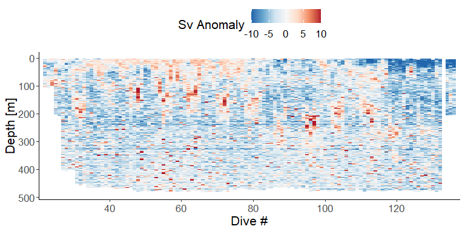

```r
#plotting the normal anomaly
plot_sv(ano1, variable = 'SvAnomal')
```

```r
#if we want to apply another filter to the anomaly calculation it is recommended to set replace=TRUE, which replaces the Sv values with the variable v which can be set to be either SvAnomal or scaledAnomaly
ano_re = anomaly(Sv$data$`1000kHz`, fun='mean', replace = TRUE, v='SvAnomal')
ano_re_med = filter2d(ano_re,x=3,y=3,fun='median')
```

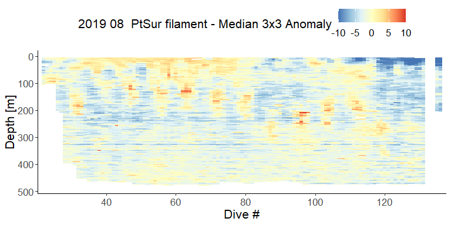

```r
plot_sv(ano_re_med, svmin = -10, svmax=10, nam=paste(str_replace_all(mission,'_',' '), expression("- Median 3x3 Anomaly", Sv['1000kHz'])))
```

## Detecting DVM

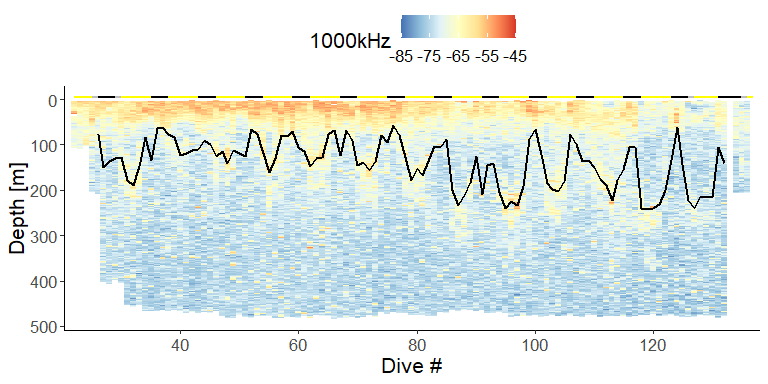

```r
dvm = pdvm(Sv$data$`1000kHz`,
         vmin=-85,
         vmax=-58,
         perc=25,
         dcut=280,scut=15,
         dskip=3,
         dend=3,
         updown='bottom')

p=Sv$plots$`1000kHz`
p+geom_line(data=dvm, aes(x=Dive, y=Depth),size=1)
```

It can be useful to try the `dvm_app(path)` function to find the optimal settings for the DVM detection for a given mission at a given freuqency. This funciton will open a shiny app in a browser window, which allows determination of the DVM optimum settings interactively.

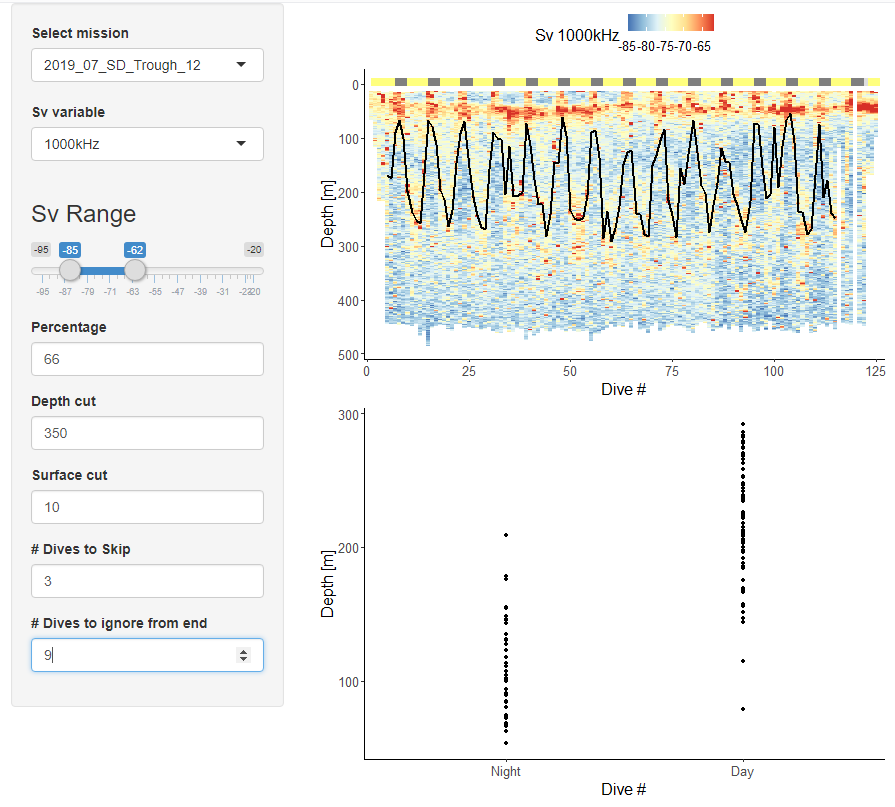

dvm app

# Using netCDF files for additional information

The ZOnar netCDF files contain more information than just the downsampled Sv information. The ZOnar netCDF files also include information about the hydrography (i.e. ambient temperature, salinity, fluorescence), GPS information and some coarse Zoocam data as well as engineering details.  
From the csv folder we can get the path (`ncpath_from_csvpath(path)`) to the netCDF files.

```r
ncpath = ncpath_from_csvpath(path)
```

## Get acoustic calibraiton information

With ZooDVM we can easily access the acoustic calibraiton information used to calculate Sv:

```r
calinfo = get_accal(ncpath, sel)
```

```
## 2020-07-27 16:35:56: a total of 16 missions were found.
```

```
## 2020-07-27 16:35:56: Selected mission - 2019_08__PtSur_filament.nc
```

```r
knitr::kable(calinfo)
```

|  | Beam 1 | Beam 2 | units | Description |
| --- | --- | --- | --- | --- |
| Frequency | 200.0000 | 1000.0000 | kHz | center Frequency |
| Counts_per_dB | 40.0000 | 40.0000 | Counts | # Counts to translate raw counts into dB re V |
| nBin | 25.0000 | 25.0000 | # | # of points to average per bin |
| nSamples | 300.0000 | 250.0000 | # | # scans to take |
| Tau | 6.0000 | 6.0000 | ms | Pulse Duration |
| Beam_deg | 9.8000 | 4.0000 | degrees | 3 dB Beam Width |
| tPing | 200.0000 | 100.0000 | ms | Interval between pings |
| tScan | 60.0000 | 50.0000 | ms | duration to take scans |
| blank | 1.0000 | 1.0000 | micro-sec | Time between end of transmit and first scan |
| dt | 200.0000 | 200.0000 | micro-sec | Period between scans (1/sampling rate in Hz) |
| Source_Level | 120.5468 | 122.4094 | dB re m2 | Source level approximation from calibration |
| Gain_system | 54.0000 | 54.0000 | dB re V | System gain defined by electronics |
| Gain_cal | -47.9700 | -40.6700 | dB re m2 | Calibration derived gain |
| Noise_cal | 1540.0000 | 1530.0000 | # | Raw noise counts during calibration |

## Getting GPS info from netCDF file

The is a simple function to extract the GPS information for a given mission (mission can be selected as an integer from the above shown list or as a string with the full mission name). Here we select mission number 15, which is the Pt Sur filament mission:

```r
sel = 15 #selected mission
gps = get_gps(ncpath, mission=sel)
```

```
## 2020-07-27 16:35:56: a total of 16 missions were found.
```

```
## 2020-07-27 16:35:56: Selected mission - 2019_08__PtSur_filament.nc
```

```
## 2020-07-27 16:35:56: Getting GPS
```

```
## 2020-07-27 16:35:57: Getting sun position/azimuth and Day/Night info
```

Plots can then easily be created using the plot_gps function. To get a bathymetry background set *bathy=TRUE*, to color points according to day and night set *daynight=TRUE* and the change the shape of the points according to the start and end points of the dive set *startend = TRUE*:

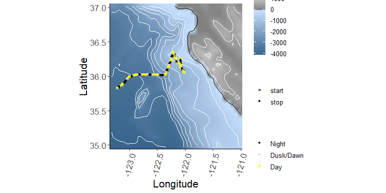

```r
plot_gps(gps, bathy=TRUE, daynight=TRUE,startend=TRUE)
```

Or without a background map:

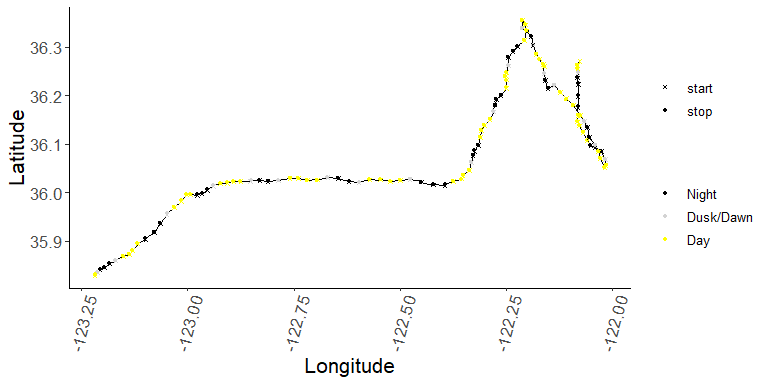

```r
plot_gps(gps, bathy=FALSE, daynight=TRUE,startend=TRUE)
```

## Getting environment info from netCDF file

```r
sel = 15 #selected mission
env = get_env(ncpath, mission=sel)
```

```
## 2020-07-27 16:36:02: a total of 16 missions were found.
```

```
## 2020-07-27 16:36:02: Selected mission - 2019_08__PtSur_filament.nc
```

```
## 2020-07-27 16:36:02: Getting GPS
```

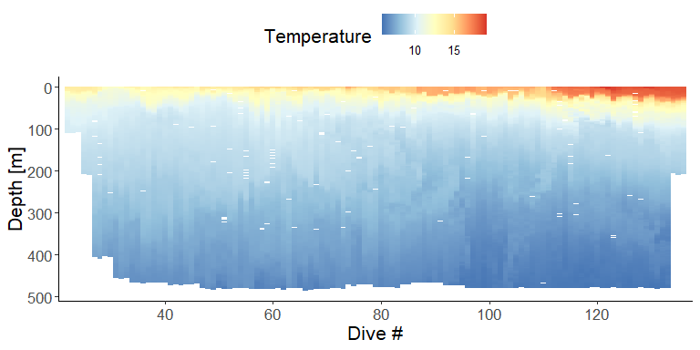

```r
plot_env(env,'temp', 'Temperature')
```

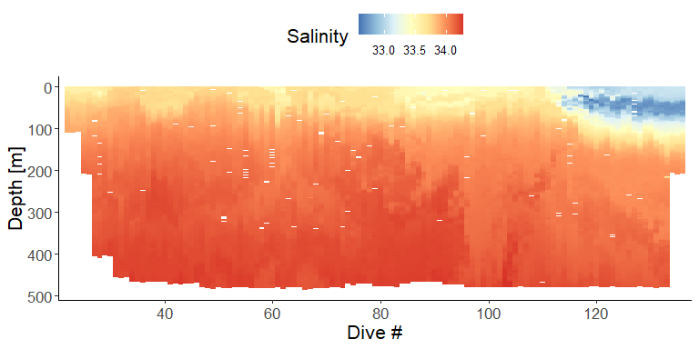

```r
plot_env(env,'sal', 'Salinity')
```

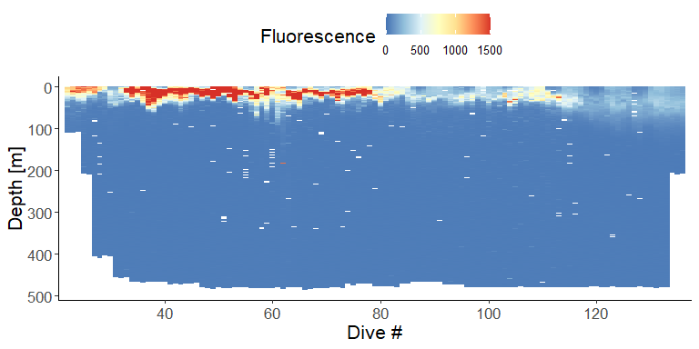

```r
plot_env(env,'fluo', 'Fluorescence', lims=c(0, 1500))
```

### Detecting thermoclines and other *clines

```r
clines=env %>%
   group_by(Dive) %>%
   summarise(thermo_c=thermocline(temp,Depth, tmax=NULL),
             fluo_c=thermocline(fluo,Depth, tmax=500, tmin=10,r=5),
             sal_c=thermocline(sal,Depth,r=5,tmin=33.4, tmax=34, cw='w'))
```

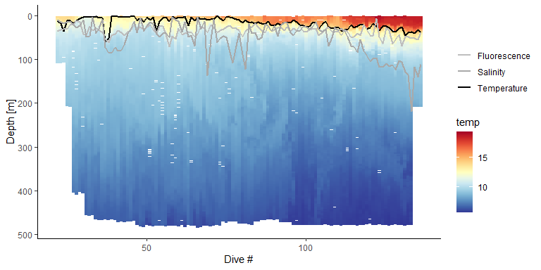

```r
p<-ggplot()+geom_tile(data=env, aes(y=Depth_r, x=Dive, fill=temp))+
   scale_y_reverse()+theme_classic()+
   scale_fill_gradientn(colors=rev(pals::brewer.rdylbu(15)))+xlab('Dive #')+ylab('Depth [m]')
 p+geom_line(data.frame(clines),mapping=aes(x=Dive,y=thermo_c, color='Temperature'),size=1)+
   geom_line(data.frame(clines),mapping=aes(x=Dive,y=fluo_c, color='Fluorescence'),size=1)+
   geom_line(data.frame(clines),mapping=aes(x=Dive,y=sal_c, color='Salinity'),size=1)+
   scale_color_manual(values = c('Temperature' = 'black',
                                 'Fluorescence' = 'gray',
                                 'Salinity' = 'darkgray'), name='')
```

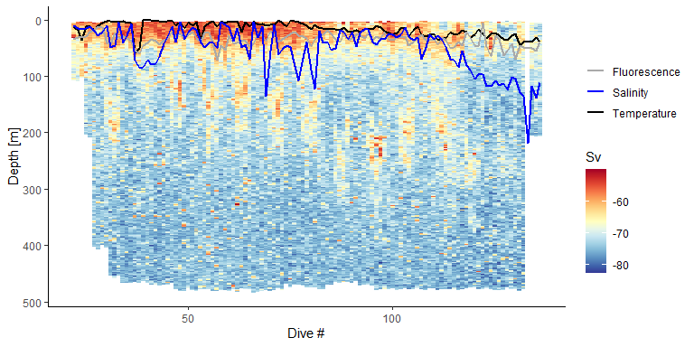

```r
p<-ggplot()+geom_tile(data=Sv$data$`1000kHz`, aes(y=Depth_r, x=Dive, fill=Sv))+
   scale_y_reverse()+theme_classic()+
   scale_fill_gradientn(colors=rev(pals::brewer.rdylbu(15)), na.value='transparent')+xlab('Dive #')+ylab('Depth [m]')
 p+geom_line(data.frame(clines),mapping=aes(x=Dive,y=thermo_c, color='Temperature'),size=1)+
   geom_line(data.frame(clines),mapping=aes(x=Dive,y=fluo_c, color='Fluorescence'),size=1)+
   geom_line(data.frame(clines),mapping=aes(x=Dive,y=sal_c, color='Salinity'),size=1)+
   scale_color_manual(values = c('Temperature' = 'black',
                                 'Fluorescence' = 'darkgray',
                                 'Salinity' = 'blue'), name='')
```